# Self-Driving Car Engineer Nanodegree

## Project: Build a Traffic Sign Recognition Classifier

## Step 0: Load The Data

```python
# Load pickled data
import pickle
import csv
import numpy as np
import pandas as pd
import math
import matplotlib
import matplotlib.pyplot as plt
from copy import deepcopy
from sklearn.utils import shuffle
import tensorflow as tf
import cv2

%matplotlib inline
%config InlineBackend.figure_formats = {'png', 'retina'}
matplotlib.rcParams['figure.figsize'] = (15.0, 8.0)
plt.rcParams.update({'font.size': 18})
matplotlib.rcParams['figure.figsize'] = (20.0, 10.0)


training_file = 'traffic-signs-data/train.p'
validation_file = 'traffic-signs-data/valid.p'
testing_file = 'traffic-signs-data/test.p'
signname_file = 'signnames.csv'

with open(training_file, mode='rb') as f:
    train = pickle.load(f)
with open(validation_file, mode='rb') as f:
    valid = pickle.load(f)
with open(testing_file, mode='rb') as f:
    test = pickle.load(f)
with open(signname_file, newline='') as csvfile:
    signnames = [row[1] for row in list(csv.reader(csvfile, delimiter=','))[1:]]

X_train_orig, y_train_orig = train['features'], train['labels']
X_valid_orig, y_valid_orig = valid['features'], valid['labels']
X_test_orig, y_test_orig = test['features'], test['labels']
```

## Step 1: Dataset Summary & Exploration

The pickled data is a dictionary with 4 key/value pairs:

- `'features'` is a 4D array containing raw pixel data of the traffic sign images, (num examples, width, height, channels).
- `'labels'` is a 1D array containing the label/class id of the traffic sign. The file `signnames.csv` contains id -> name mappings for each id.
- `'sizes'` is a list containing tuples, (width, height) representing the original width and height the image.
- `'coords'` is a list containing tuples, (x1, y1, x2, y2) representing coordinates of a bounding box around the sign in the image. **THESE COORDINATES ASSUME THE ORIGINAL IMAGE. THE PICKLED DATA CONTAINS RESIZED VERSIONS (32 by 32) OF THESE IMAGES**

Complete the basic data summary below. Use python, numpy and/or pandas methods to calculate the data summary rather than hard coding the results. For example, the [pandas shape method](http://pandas.pydata.org/pandas-docs/stable/generated/pandas.DataFrame.shape.html) might be useful for calculating some of the summary results.

### Provide a Basic Summary of the Data Set Using Python, Numpy and/or Pandas

```python
n_train = len(y_train_orig)

n_validation = len(y_valid_orig)

n_test = len(y_test_orig)

image_shape = X_train_orig[0].shape

n_classes = len(set(y_train_orig))

# Make sure all datasets have all classes:
assert(list(set(y_train_orig)) == list(range(n_classes)))
assert(list(set(y_test_orig)) == list(range(n_classes)))
assert(list(set(y_valid_orig)) == list(range(n_classes)))

print("Number of training examples =", n_train)
print("Number of validation examples =", n_validation)
print("Number of testing examples =", n_test)
print("Image data shape =", image_shape)
print("Number of classes =", n_classes)
```

```
Number of training examples = 34799
Number of validation examples = 4410
Number of testing examples = 12630
Image data shape = (32, 32, 3)
Number of classes = 43
```

### Include an exploratory visualization of the dataset

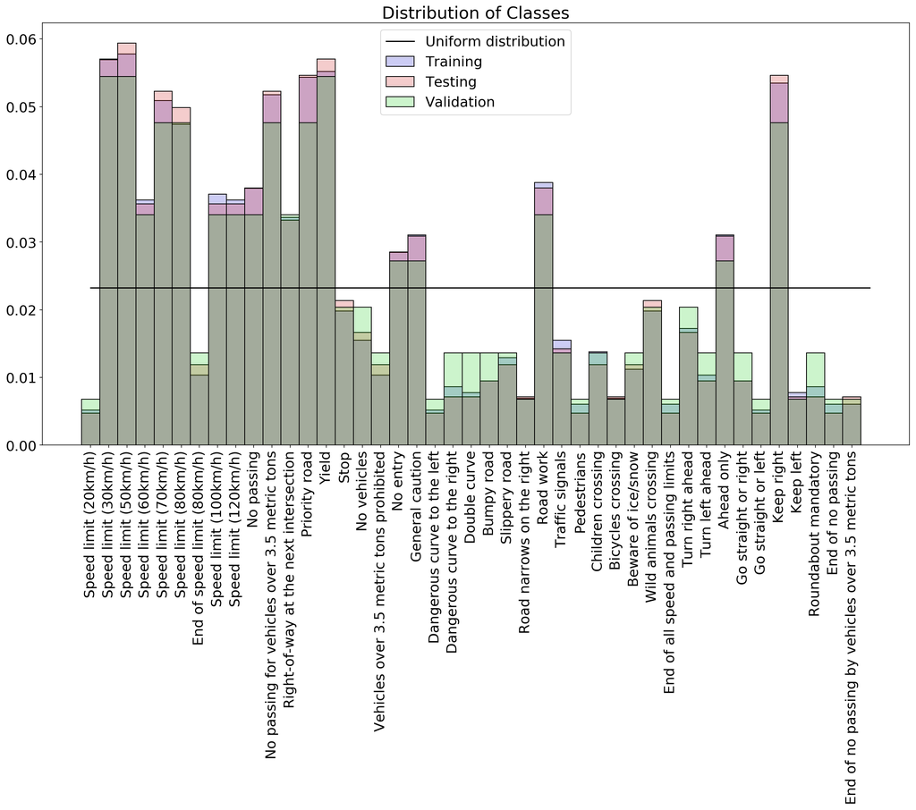

```python
# Plot histograms of the classes for the different data sets
x = range(n_classes+1)
hline = [1 / n_classes] * len(x)

fig, ax = plt.subplots()
ax.plot(x, hline, c='black', label="Uniform distribution")

ax.hist(y_train_orig, bins=x, density=True, align="left", label="Training", fc=(0, 0, 0.8, 0.2), ec='black')
ax.hist(y_test_orig, bins=x, density=True, align="left", label="Testing", fc=(0.8, 0, 0, 0.2), ec='black')
ax.hist(y_valid_orig, bins=x, density=True, align="left", label="Validation", fc=(0, 0.8, 0, 0.2), ec='black')
plt.legend()

plt.xticks(range(n_classes), signnames, rotation='vertical')
plt.title("Distribution of Classes")
plt.show()
```

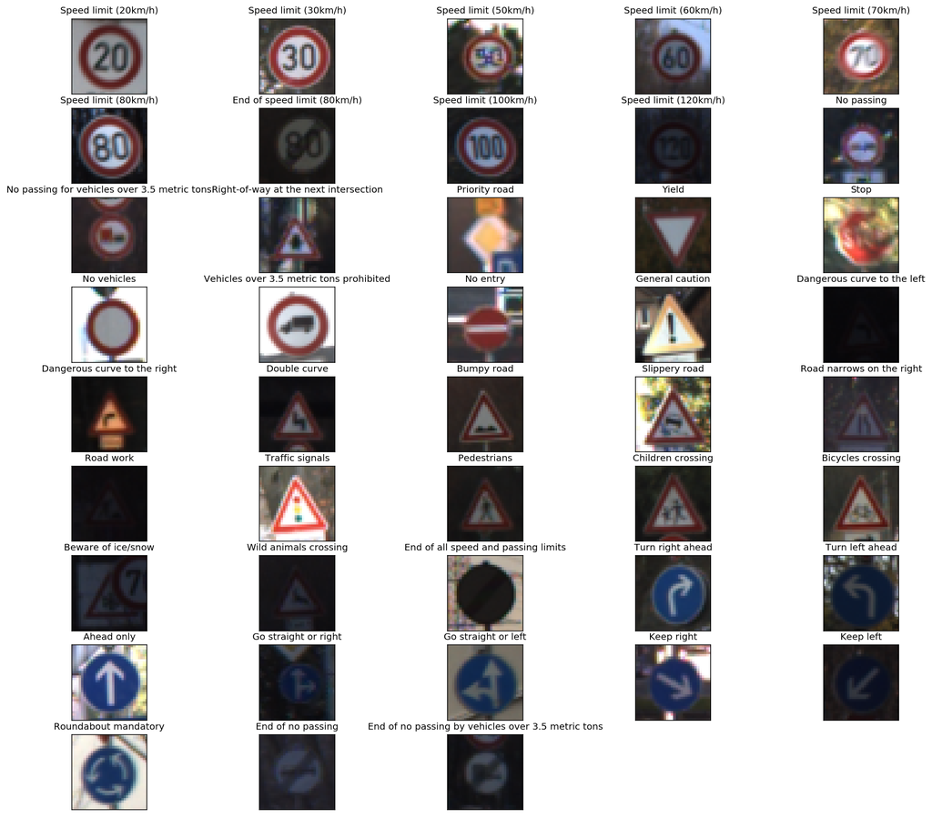

```python
def plot_random_img_samples(X=X_train_orig, y=y_train_orig, gray=False, n_img_columns=5):
    # Get one random sample of each class:
    sign_examples_idx = [np.random.choice(np.ravel(np.where(y==img_class))) for img_class in range(n_classes)]

    n_img_rows = math.ceil(n_classes / n_img_columns)
    fig = plt.figure(figsize=(16, 16))

    for img_class, data_idx in enumerate(sign_examples_idx):
        ax = fig.add_subplot(n_img_rows, n_img_columns, img_class+1)
        sign_index = sign_examples_idx[img_class]
        if gray:
            ax.imshow(X[sign_index][:,:,0], interpolation='nearest', cmap='gray')
        else:
            ax.imshow(X[sign_index], interpolation='nearest')

        plt.title(signnames[img_class], fontsize=10)
        plt.tick_params(axis='both', which='both', bottom=False, top=False, labelbottom=False, right=False, left=False, labelleft=False)

    fig.subplots_adjust(wspace=1.5, hspace=0)
    plt.show()

plot_random_img_samples()
```

## Step 2: Design and Test a Model Architecture

### Pre-process the Data Set (normalization, grayscale, etc.)

```python
def preprocess(img):
    new_img = deepcopy(img)
    new_img = cv2.cvtColor(new_img, cv2.COLOR_RGB2GRAY)[:,:, np.newaxis]
    new_img = np.divide((new_img.astype(float) - 128.0), 128.0)
    return new_img
```

```python
# Normalize and shuffle training data:
y_train = deepcopy(y_train_orig)
X_train = [preprocess(img) for img in X_train_orig]
X_train, y_train = shuffle(X_train, y_train)

# Normalize validation data
y_valid = deepcopy(y_valid_orig)
X_valid = [preprocess(img) for img in X_valid_orig]

# Normalize test data
y_test = deepcopy(y_test_orig)
X_test = [preprocess(img) for img  in X_test_orig]
```

[figure not shown]

```python
plot_random_img_samples(X=X_train, y=y_train, gray=True)
```

### Model Architecture

```python
from tensorflow.contrib.layers import flatten

def LeNet(x, mu=0, sigma=0.1):
    # Layer 1: Convolutional. Input = 32x32x1. Output = 28x28x6.
    fw1 = tf.Variable(tf.random_normal([5, 5, 1, 6], mean=mu, stddev=sigma))
    st1 = [1, 1, 1, 1]
    fb1 = tf.Variable(tf.random_normal([6], mean=mu, stddev=sigma))

    conv1 = tf.nn.conv2d(x, fw1, st1, padding='VALID')
    conv1 = tf.nn.bias_add(conv1, fb1)
    # Activation.
    conv1 = tf.nn.relu(conv1)

    # Pooling. Input = 28x28x6. Output = 14x14x6.
    pool1 = tf.nn.max_pool(conv1, ksize=[1, 2, 2, 1], strides=[1, 2, 2, 1], padding='SAME')
    pool1 = tf.nn.dropout(pool1, keep_rate_conv)

    # Layer 2: Convolutional. Output = 10x10x16.
    fw2 = tf.Variable(tf.random_normal([5, 5, 6, 16], mean=mu, stddev=sigma))
    st2 = [1, 1, 1, 1]
    fb2 = tf.Variable(tf.random_normal([16], mean=mu, stddev=sigma))

    conv2 = tf.nn.conv2d(pool1, fw2, st2, padding='VALID')
    conv2 = tf.nn.bias_add(conv2, fb2)
    # Activation.
    conv2 = tf.nn.relu(conv2)

    # Pooling. Input = 10x10x16. Output = 5x5x16.
    pool2 = tf.nn.max_pool(conv2, ksize=[1, 2, 2, 1], strides=[1, 2, 2, 1], padding='SAME')
    pool2 = tf.nn.dropout(pool2, keep_rate_conv)


    # Flatten. Input = 5x5x16. Output = 400.
    fc1 = flatten(pool2)

    # Layer 3: Fully Connected. Input = 400. Output = 120.
    fw3 = tf.Variable(tf.random_normal([400, 120], mean = mu, stddev = sigma))
    fb3 = tf.Variable(tf.random_normal([120], mean = mu, stddev = sigma))

    fc1 = tf.add(tf.matmul(fc1, fw3), fb3)
    # Activation.
    fc1 = tf.nn.relu(fc1)
    fc1 = tf.nn.dropout(fc1, keep_rate_fc)

    # Layer 4: Fully Connected. Input = 120. Output = 84.
    fw4 = tf.Variable(tf.random_normal([120, 84], mean = mu, stddev = sigma))
    fb4 = tf.Variable(tf.random_normal([84], mean = mu, stddev = sigma))

    fc2 = tf.add(tf.matmul(fc1, fw4), fb4)
    # Activation.
    fc2 = tf.nn.relu(fc2)
    fc2 = tf.nn.dropout(fc2, keep_rate_fc)

    # Layer 5: Fully Connected. Input = 84. Output = 34.
    fw5 = tf.Variable(tf.random_normal([84, n_classes], mean=mu, stddev=sigma))
    fb5 = tf.Variable(tf.random_normal([n_classes], mean=mu, stddev=sigma))

    logits = tf.add(tf.matmul(fc2, fw5), fb5)
    all_weights = [fw1, fw2, fw3, fw4, fw5] # Return these for weight regularization

    return logits, all_weights
```

### Train, Validate and Test the Model

```python
EPOCHS = 50
BATCH_SIZE = 128
LEARNING_RATE = 0.001
ENABLE_L2 = True
ENABLE_DROPOUT = True
ENABLE_COST_WEIGHTING = True
KEEP_RATE_CONV = 1.0 # Keep rate of first fully connected layer
KEEP_RATE_FC = 0.55 # Keep rate of first fully connected layer
BETA = 0.0005 # L2 regularization penalty factor

if not ENABLE_DROPOUT:
    KEEP_RATE_CONV = 1.0
    KEEP_RATE_FC = 1.0
```

```python
# Class weights for cost function
y_tot = np.concatenate((y_train, y_test))
class_weights = float(len(y_tot)) / np.bincount(y_tot) # 1 divided by class fraction in data set
class_weights = tf.constant(class_weights, dtype=tf.float32)
```

```python
x = tf.placeholder(tf.float32, (None, 32, 32, 1))
y = tf.placeholder(tf.int32, (None))
one_hot_y = tf.one_hot(y, n_classes)
keep_rate_conv = tf.placeholder(tf.float32)
keep_rate_fc = tf.placeholder(tf.float32)
```

## Training Pipeline

```python
logits, model_weights = LeNet(x)
cross_entropy = tf.nn.softmax_cross_entropy_with_logits(labels=one_hot_y, logits=logits)

if ENABLE_COST_WEIGHTING:
    weights = tf.reduce_sum(class_weights * one_hot_y, axis=1)
    cross_entropy = cross_entropy * weights

if ENABLE_L2:
    L2 = BETA * tf.nn.l2_loss(model_weights[0])
    for w in model_weights[1:]:
        L2 += BETA * tf.nn.l2_loss(w)
    loss_operation = tf.reduce_mean(cross_entropy + L2)
else:
    loss_operation = tf.reduce_mean(cross_entropy)

optimizer = tf.train.AdamOptimizer(learning_rate=LEARNING_RATE)
training_operation = optimizer.minimize(loss_operation)
```

## Model Evaluation

```python
correct_prediction = tf.equal(tf.argmax(logits, 1), tf.argmax(one_hot_y, 1))
accuracy_operation = tf.reduce_mean(tf.cast(correct_prediction, tf.float32))
saver = tf.train.Saver()

def evaluate(X_data, y_data):
    num_examples = len(X_data)
    total_accuracy = 0
    sess = tf.get_default_session()
    for offset in range(0, num_examples, BATCH_SIZE):
        batch_x, batch_y = X_data[offset:offset+BATCH_SIZE], y_data[offset:offset+BATCH_SIZE]
        accuracy = sess.run(accuracy_operation, feed_dict={x: batch_x, y: batch_y, keep_rate_fc: 1.0, keep_rate_conv: 1.0})
        total_accuracy += (accuracy * len(batch_x))
    return total_accuracy / num_examples
```

## Model Training

```python
def train_model(X_train=X_train, y_train=y_train, X_valid=X_valid, y_valid=y_valid, model_name="./lenet"):
    train_acc = []
    valid_acc = []

    with tf.Session() as sess:
        sess.run(tf.global_variables_initializer())
        num_examples = len(X_train)

        print("Training...")
        print()
        for i in range(EPOCHS):
            X_train, y_train = shuffle(X_train, y_train)
            for offset in range(0, num_examples, BATCH_SIZE):
                end = offset + BATCH_SIZE
                batch_x, batch_y = X_train[offset:end], y_train[offset:end]
                sess.run(training_operation, feed_dict={x: batch_x, y: batch_y, keep_rate_fc: KEEP_RATE_FC, keep_rate_conv: KEEP_RATE_CONV})

            training_accuracy = evaluate(X_train, y_train)
            validation_accuracy = evaluate(X_valid, y_valid)
            train_acc += [training_accuracy]
            valid_acc += [validation_accuracy]
            print("EPOCH {} ...".format(i+1))
            print("Training Accuracy = {:.3f}".format(training_accuracy) + ",    Validation Accuracy = {:.3f}".format(validation_accuracy))

        saver.save(sess, model_name)
        print("Model saved: ", model_name)
    return np.array(train_acc) * 100, np.array(valid_acc) * 100
```

```python
train_acc, valid_acc = train_model()
```

```
Training...

EPOCH 1 ...
Training Accuracy = 0.561,    Validation Accuracy = 0.520
EPOCH 2 ...
Training Accuracy = 0.780,    Validation Accuracy = 0.765
EPOCH 3 ...
Training Accuracy = 0.853,    Validation Accuracy = 0.828
EPOCH 4 ...
Training Accuracy = 0.893,    Validation Accuracy = 0.870
EPOCH 5 ...
Training Accuracy = 0.916,    Validation Accuracy = 0.888
EPOCH 6 ...
Training Accuracy = 0.934,    Validation Accuracy = 0.913
EPOCH 7 ...
Training Accuracy = 0.945,    Validation Accuracy = 0.909
EPOCH 8 ...
Training Accuracy = 0.957,    Validation Accuracy = 0.923
EPOCH 9 ...
Training Accuracy = 0.961,    Validation Accuracy = 0.929
EPOCH 10 ...
Training Accuracy = 0.964,    Validation Accuracy = 0.936
EPOCH 11 ...
Training Accuracy = 0.968,    Validation Accuracy = 0.921
EPOCH 12 ...
Training Accuracy = 0.973,    Validation Accuracy = 0.942
EPOCH 13 ...
Training Accuracy = 0.976,    Validation Accuracy = 0.941
EPOCH 14 ...
Training Accuracy = 0.977,    Validation Accuracy = 0.939
EPOCH 15 ...
Training Accuracy = 0.975,    Validation Accuracy = 0.934
EPOCH 16 ...
Training Accuracy = 0.979,    Validation Accuracy = 0.951
EPOCH 17 ...
Training Accuracy = 0.983,    Validation Accuracy = 0.949
EPOCH 18 ...
Training Accuracy = 0.982,    Validation Accuracy = 0.940
EPOCH 19 ...
Training Accuracy = 0.986,    Validation Accuracy = 0.950
```

[output cut: 48 more lines]

```
EPOCH 44 ...
Training Accuracy = 0.996,    Validation Accuracy = 0.958
EPOCH 45 ...
Training Accuracy = 0.996,    Validation Accuracy = 0.965
EPOCH 46 ...
Training Accuracy = 0.996,    Validation Accuracy = 0.962
EPOCH 47 ...
Training Accuracy = 0.997,    Validation Accuracy = 0.969
EPOCH 48 ...
Training Accuracy = 0.996,    Validation Accuracy = 0.964
EPOCH 49 ...
Training Accuracy = 0.995,    Validation Accuracy = 0.963
EPOCH 50 ...
Training Accuracy = 0.997,    Validation Accuracy = 0.968
Model saved:  ./lenet
```

```python
def plot_acc_v_epoch(train_acc, valid_acc):
    plt.plot(train_acc, label="Training accuracy")
    plt.plot(valid_acc, label="Validation accuracy")
    plt.yticks(range(85,101))
    plt.ylim([85, 100])
    plt.xticks(range(len(train_acc)))
    plt.tick_params(labelright=True)
    plt.legend()
    plt.grid(color='k', linestyle=':', linewidth=1)
    plt.ylabel("Accuracy [%]")
    plt.xlabel("Epoch")

    l2_str = "Enabled" if ENABLE_L2 else "Disabled"
    do_str = "Enabled" if ENABLE_DROPOUT else "Disabled"
    cw_str = "Enabled" if ENABLE_COST_WEIGHTING else "Disabled"
    title = "L2 Regularization: " + l2_str + ", Dropout: " + do_str + ", Class Weighting: " + cw_str + ", LEARNING_RATE: " + str(LEARNING_RATE)
    plt.title(title)
    plt.show()
```

[figure not shown]

```python
plot_acc_v_epoch(train_acc, valid_acc)
```

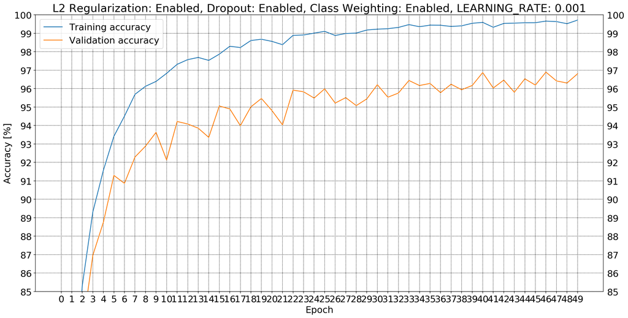

```python
plot_acc_v_epoch(train_acc, valid_acc)
```

## Evaluate Model On Test Data Set

```python
with tf.Session() as sess:
    saver.restore(sess, tf.train.latest_checkpoint('./best_model'))

    test_accuracy = evaluate(X_test, y_test)
    print("Test Accuracy = {:.3f}".format(test_accuracy))
```

```
INFO:tensorflow:Restoring parameters from ./best_model/lenet
Test Accuracy = 0.939
```

## Step 3: Test a Model on New Images

To give yourself more insight into how your model is working, download at least five pictures of German traffic signs from the web and use your model to predict the traffic sign type.

You may find `signnames.csv` useful as it contains mappings from the class id (integer) to the actual sign name.

### Load and Output the Images

```python
dir_path = "new_sign_images/"
filenames = ["dangerous_curve.jpg", "children_crossing.jpg", "priority_and_speed.png", "straight_or_left.png", "120.jpeg"]
X_new_orig = [cv2.cvtColor(cv2.imread(dir_path + img_name), cv2.COLOR_BGR2RGB) for img_name in filenames]
y_new_orig = [20, 28, 12, 37, 8]

# Preprocess data:
X_new = np.array([preprocess(img) for img in deepcopy(X_new_orig)])
y_new = np.array(deepcopy(y_new_orig))
```

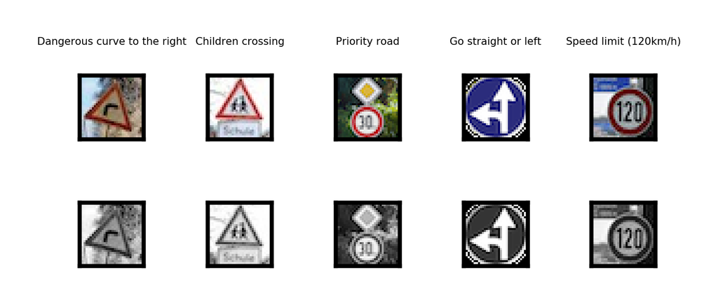

```python
# Plot images:
columns = 5
fig = plt.figure(figsize=(2, columns), dpi=380)

for i, (x_orig, x_n, y_n) in enumerate(zip(X_new_orig, X_new, y_new_orig)):
    ax = fig.add_subplot(2, columns, 1+i)
    ax.imshow(x_orig, interpolation='nearest')
    plt.title(signnames[y_n], fontsize=2)
    plt.tick_params(axis='both', which='both', bottom=False, top=False, labelbottom=False, right=False, left=False, labelleft=False)

    ax = fig.add_subplot(2, columns, columns+i+1)
    ax.imshow(x_n[:,:,0], interpolation='nearest', cmap="gray")
    plt.tick_params(axis='both', which='both', bottom=False, top=False, labelbottom=False, right=False, left=False, labelleft=False)

    fig.subplots_adjust(wspace=1, hspace=-0.9)
plt.show()
```

### Predict the Sign Type for Each Image

```python
def predict_sign(X_input, k=5):
    with tf.Session() as sess:
        saver.restore(sess, tf.train.latest_checkpoint('./best_model'))
        y_probabilities, y_predicted = sess.run(tf.nn.top_k(tf.nn.softmax(logits), k=k), feed_dict={x: X_input, keep_rate_fc: 1.0, keep_rate_conv: 1.0})

    return y_probabilities, y_predicted
```

### Analyze Performance

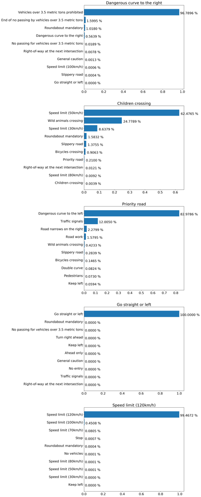

```python
def plot_prob_hist(y_prob, y_pred, y_true):
    y_ticks = list(reversed(range(len(y_prob))))
    plt.barh(y_ticks, y_prob)
    plt.yticks(y_ticks, [signnames[idx] for idx in y_pred])
    plt.title(signnames[y_true])
    for i, v in enumerate(y_prob):
        plt.text( v + 0.01, y_ticks[i] - 0.25, "{:.4f} %".format(100*v))


plt.figure(figsize=(10,50))

for i, (y_prob, y_pred, y_true) in enumerate(zip(y_probabilities, y_predicted, y_new)):
    plt.subplot(5, 1, i+1)
    plot_prob_hist(y_prob, y_pred, y_true)
plt.show()
```